# RMT Project

Naika Dorilas

March 4, 2019

Given time series data and model $y'=Ay+\xi$, the goal is to find $\mu$, $\sigma$ and d of the matrix A which make this data the most probable.

# Simulated Data

We use the stochastic version of our model for species abundance of the $i^{th}$ species $\frac{y_i(t+\Delta t)-y_i(t)}{\Delta t}=\sum_{ij}A_{ij}y_i+\xi_i$ to find our species abundance at time j So we will use the following code to create an interaction matrix which is symmetric, A. First we create a function to create symmetric matrices A, of mean $\mu=-1$, variance $\sigma=0.5$ and diagonal elements, $d=-10$.

```r
S=20 #matrix size
mu=-1 #mean
sigma=0.5 #deviation
d=10 #diagonal elements
N=40 #number of data points per species

A=makeASymmetric(mu=mu,sigma=sigma,d=-d, S=S)
```

```r
S=50 #matrix size
mu=-1 #mean
sigma=0.5 #deviation
d=10 #diagonal elements
N=500 #number of data points per species

A=makeASymmetric(mu=mu,sigma=sigma,d=-d, S=S)

if(errorND(A)==1)
{
  print("Error: The matrix is not diagonally stable")
} else

{
  ###Variables


  dt=0.01 #time steps
  #yint=rnorm(mean=7, sd=3,n=10) #initial condition
  yint=1



  y<-createTS(A=A,dt=dt,y0=yint,N=N,sigma=15)

}
```

This is just one method. Now we try a different method for generating time series data by assuming that the data comes directly from a multivariate distribution of mean, variance and diagonal elements equal to that which we us to create A.

```r
S=50 #matrix size
mu=-1 #mean
sigma=0.5 #deviation
d=10 #diagonal elements
N2=100 #number of data points per species

#A=makeASymmetric(mu=mu,sigma=sigma,d=-d, S=S)

y2=matrix(0,nrow=S, ncol=N2) #population
y2=makeX(mu=mu, sigma=sigma, d=d, S=S, N=N2)
```

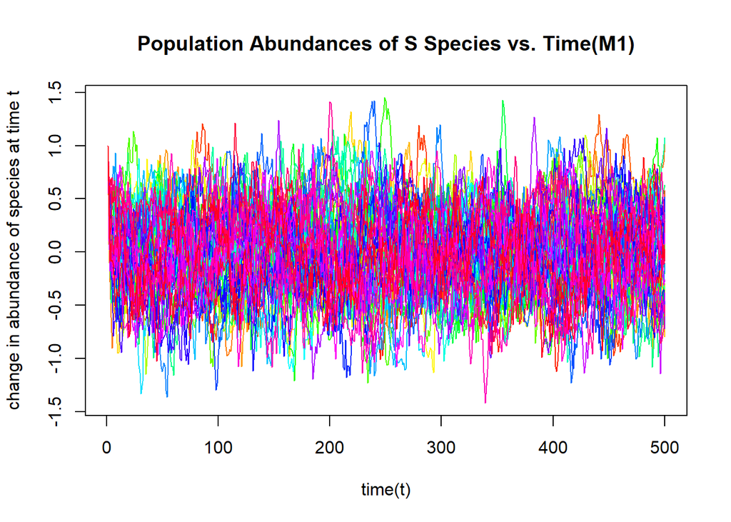

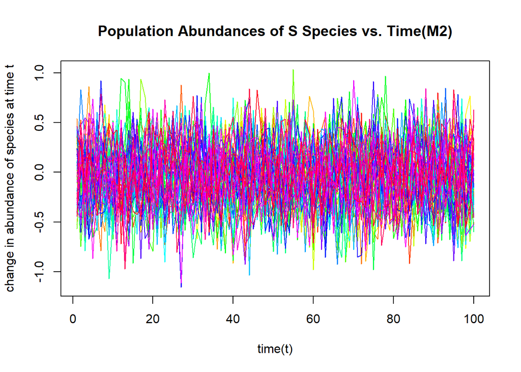

Now we need 3 functions. One to generate symmetric matrices A which is included in myRfunctions.R, one to create time seires data for which there are two options in myRfunctions.R, and one to calculate $P(X|A)=\dfrac{(detA)^{N/2}}{(2\pi)^{NS/2}} exp(-\dfrac{1}{2}\sum_{a=1}^{N}\sum_{ij}^S x_i^a A_{ij} x_j^a)$. We compute $\sum_{a=1}^{N}\sum_{ij}^S x_i^a A_{ij} x_j^a$ by finding $\sum_{i=j}X^TAX$ and use the log probability to make the numbers more manageable.

```r
P_x<-function(X, A)
{
    # note: we're always returning the log of P(X|A)

    S=nrow(A)
    N=ncol(X)

    #determinant returns a list of the absolute value of the determinat(modulus) and the        sign
    logDA = determinant(A, logarithm = TRUE)
    logDA = logDA$modulus * logDA$sign

    out <- N/2 * (logDA - S * log(2 * pi)) - 1/2 * sum(diag(t(X)%*%A%*%X))

    return(as.numeric(out))
}
```

# Maximum Likelihood

## Monte Carlo Integral

Given an SxN matrix of times series data X, our goal is to find the average probability, $P(X|\mu,\sigma,d)$. We use a function created to compute the Monte Carlo Integral, B times for 1 set of $\mu,\sigma,d$

Then we optimize this for one set of $\mu, \sigma, d$ to see if it can infer parameters close to the actual parameters which were used to make the data. We use the L-BFGS-B algorithm- a limited-memory quasi-Newton code for bound-constrained optimization with constrainst [$\mu,\sigma,d$]$\rightarrow[-10,0,0]:[10,10,100]$

```r
mu=2
sigma=1.5
d=15
S=30
N=100
B=100

X=makeX(mu,sigma,d,S,N)
optim(par=c(mu,sigma,d),fn=.mc2opt,X=X,B=B, method = 'L-BFGS-B',
      lower = c(-10, 0, 0), upper = c(10, 10, 100),
      control = list(fnscale = -1))
```

```
## $par
## [1]  2.000306  1.500325 15.003253
##
## $value
## [1] -7762.736
##
## $counts
## function gradient
##       13       13
##
## $convergence
## [1] 0
##
## $message
## [1] "CONVERGENCE: REL_REDUCTION_OF_F <= FACTR*EPSMCH"
```

```r
dat<-read.csv('../Data/monte_carlo_optimization/mcEstimates_symmetricA.csv')
```

```r
muV=seq(-2,2,by=0.5)
sigmaV=seq(0,1, by =0.2)
dV=seq(5, 10, by=1)

params=expand.grid(muV,sigmaV,dV)
#params
```